# Los eventos de campaña y la intención de voto

Qué nos dice el tracking diario de 40dB sobre la primera semana de campaña del 29-N

Autores/as

Jordi Muñoz

Claude

Fecha de publicación

20 de noviembre de 2026

Versió en català · English version

## Resumen

La primera semana de campaña de las elecciones generales del 29 de noviembre ha movido poco la intención de voto. La mayoría de los eventos que han ocupado a los medios, como la huelga general por la vivienda, las cargas policiales, el programa del PSOE o la noticia de que la mujer de Abascal había cobrado el bono social térmico, no dejan ningún rastro visible en las encuestas diarias de 40dB.

La excepción es el 13 de noviembre, el día en que empezó oficialmente la campaña. Ese día Vox presentó su programa, Santiago Abascal canceló a última hora una entrevista con el youtuber Jordi Wild y laSexta emitió el primer debate. Entre los encuestados de los días posteriores, Vox tiene unos 3,9 puntos menos de intención de voto que entre los de los días anteriores, y la proporción que considera a Abascal el mejor presidente baja unos 4,5 puntos. Una parte de esa pérdida vuelve al PP, que recupera a algunos de sus votantes de 2023 que se habían pasado a Vox, y el PSOE también gana terreno, aunque ninguna de las dos subidas es tan sólida como la caída de Vox. La caída de Vox parece más intensa entre los hombres jóvenes, aunque esa estimación es poco precisa.

No podemos saber cuál de los eventos del 13 de noviembre lo ha provocado, porque todos ocurrieron el mismo día. Las encuestas diarias solo detectan cambios grandes, de cuatro o cinco puntos; los efectos más pequeños pasan desapercibidos. Los detalles de los datos, el método y todas las comprobaciones están en el anexo técnico.

## 1 Qué ha pasado durante la primera semana de campaña

La cobertura periodística tiende a tratar cada día de campaña como decisivo: un debate, un desliz o una entrevista cancelada se leen como puntos de inflexión. La ciencia política ha sido tradicionalmente más escéptica. La visión dominante, que resume Shaw (1999), es que los eventos de campaña rara vez tienen efectos fuertes, porque la mayoría de los votantes les presta poca atención, decide a partir de señales partidistas y del estado de la economía, y recibe información equilibrada de las campañas rivales. El análisis del propio Shaw sobre las presidenciales de Estados Unidos entre 1952 y 1992 matiza esta visión: algunos eventos, como los debates y las convenciones, produjeron cambios significativos y relativamente duraderos, mientras que la mayoría tuvo efectos nulos o pasajeros, y analizarlos todos juntos oculta los que sí importan. La pregunta, por tanto, es qué eventos de esta campaña, si es que alguno, han movido a los votantes.

### 1.1 Una campaña estable

40dB entrevista cada día a unas 500 personas nuevas para *El País* y la SER (40dB 2026b). El 17 de noviembre *El País* publicó su estimación de voto con el titular [«Vox se frena y cede terreno al PP»](https://elpais.com/espana/elecciones-generales/2026-11-17/vox-se-frena-y-cede-terreno-al-pp.html) (El País 2026). Aquí trabajamos con las respuestas individuales de las encuestas: si comparamos las de días sucesivos, podemos ver si la opinión se mueve después de cada evento. La Figura 1 muestra la intención de voto de los principales partidos en cada muestra diaria, desde la encuesta preelectoral del 2 al 4 de noviembre hasta el 19 de noviembre.

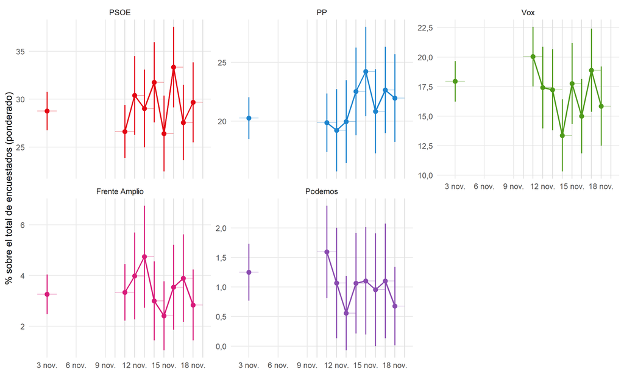

Figura 1: Intención directa de voto (porcentaje sobre el total de encuestados). Cada punto es una muestra distinta; la línea vertical de cada punto indica el margen de error y la línea horizontal, los días en que se hicieron las entrevistas. Las líneas grises verticales marcan los días con eventos relevantes.

Las líneas se mueven, pero la mayor parte de esos movimientos son ruido: con 500 entrevistas, una estimación del 20 % tiene un margen de error de unos 3,5 puntos arriba o abajo, y una del 30 %, de unos 4 puntos. Frente Amplio y Podemos se mantienen dentro de ese margen toda la semana. El movimiento más claro es la caída de Vox a partir del 14 de noviembre: toca mínimo (13,4 %) entre el 14 y el 15 y desde entonces se mantiene por debajo de su nivel del 10 al 12 de noviembre, aunque entre el 17 y el 18 se recupera hasta un 18,9 %, cerca de donde empezó, y entre el 18 y el 19 vuelve a bajar a un 15,8 %. El PP pasa de un 19,9 % entre el 10 y el 12 de noviembre a un 24,2 % entre el 15 y el 16, vuelve a bajar a un 20,8 % entre el 16 y el 17 y se sitúa en un 22,7 % y un 22,0 % en las dos muestras siguientes. El PSOE sube y baja de un día a otro y alcanza su cifra más alta, un 33,4 %, entre el 16 y el 17 de noviembre.

### 1.2 El 13 de noviembre, Vox retrocede y el PP recupera votantes

El 13 de noviembre empezó oficialmente la campaña. Vox presentó un programa centrado en la deportación de migrantes y la “prioridad nacional” en el acceso a la vivienda. Abascal canceló la entrevista que tenía programada con Jordi Wild unas horas antes de grabarla, mientras que Sánchez, Feijóo y Colau sí participaron; la decisión fue criticada incluso por voces cercanas a Vox. Por la noche, laSexta emitió el debate económico entre los portavoces de los cuatro grandes partidos.

La Figura 2 compara a las 1.000 personas entrevistadas entre el 10 y el 12 de noviembre con las 2.500 entrevistadas entre el 14 y el 19. La intención de voto a Vox pasa de un 20,0 % a un 16,2 %, y la proporción que ve a Abascal como el mejor presidente, de un 21,1 % a un 16,6 %. El PP sube de un 19,9 % a un 22,4 %, y Feijóo como mejor presidente, de un 21,0 % a un 22,8 %. La caída de Vox y de Abascal es el resultado más claro de los datos, y se mantiene con todas las formas alternativas de hacer el cálculo que hemos probado, aunque al corregir por las muchas comparaciones que hacemos deja de ser concluyente por sí sola. La subida del PP es menos segura: se queda a las puertas de la significación en la especificación principal (p = 0,074) y solo es significativa en 2 de las 8 especificaciones. Lo mismo ocurre con el PSOE, que sube de un 26,6 % a un 29,8 % (p = 0,071; significativa en 2 especificaciones); la subida de Sánchez como mejor presidente está dentro del margen de error.

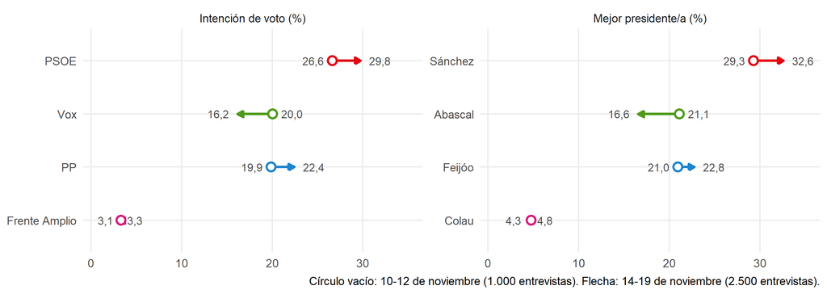

Figura 2: Intención de voto y preferencia por el mejor presidente antes y después del 13 de noviembre (porcentajes ponderados).

¿Quién se mueve? Entre quienes dicen haber votado al PP en 2023, la proporción que vuelve a votar al PP pasa del 67 % al 76 %, y la que declara voto a Vox baja unos 7 puntos. Los votantes de Vox de 2023 siguen igual de fieles. Lo que vemos, por tanto, es el regreso al PP de votantes del PP que se habían pasado a Vox, y no una pérdida del núcleo de Vox.

La caída parece más intensa entre los hombres de 18 a 34 años: la intención de voto a Vox en este grupo pasa de un 30,3 % a un 21,9 %. Es lo que cabría esperar si la cancelación de la entrevista con Jordi Wild, que tiene una audiencia sobre todo joven y masculina, hubiera perjudicado a Abascal. La diferencia, sin embargo, no es estadísticamente significativa: se basa en solo 103 entrevistas antes del 13 de noviembre y 250 después, y debe leerse con prudencia.

No podemos atribuir el cambio a un solo evento. El inicio de campaña, el programa de Vox, la renuncia a la entrevista y el debate de laSexta coincidieron el mismo día, y los datos no permiten separarlos. Además, la muestra del 10 al 12 de noviembre ya tenía un nivel de Vox algo más alto que la encuesta de principios de noviembre; una parte de la caída podría ser simplemente una vuelta a la normalidad. Incluso teniéndolo en cuenta, la caída de Vox se mantiene, aunque es menor (unos 2,5 puntos).

### 1.3 La huelga general y las cargas policiales no mueven el voto

La huelga general por la vivienda del 11 de noviembre, las cargas policiales contra los manifestantes y el respaldo de Sánchez al ministro del Interior, Fernando Grande-Marlaska, al día siguiente podían haber alejado a votantes de izquierda del PSOE hacia Frente Amplio o Podemos. No lo observamos: entre los votantes del PSOE y de Sumar de 2023, la intención de voto a Frente Amplio y a Podemos apenas cambia (menos de un punto) y el PSOE no pierde terreno. En este caso la única comparación posible es con la encuesta del 2 al 4 de noviembre, realizada una semana antes y con otros eventos de por medio, de modo que la conclusión es más débil. Un efecto pequeño, de uno o dos puntos, no podríamos detectarlo.

### 1.4 Hernani y Canarias: imposible separarlo del 13 de noviembre

El 14 de noviembre un grupo de personas atacó una carpa informativa del PP en Hernani, y ese fin de semana se registró un récord de llegadas de cayucos a Canarias. Entre el 15 y el 19 de noviembre el PP tiene unos 2,8 puntos más que antes. La diferencia es significativa en la especificación principal (p = 0,037), pero no tras corregir por comparaciones múltiples, y es imposible separarla de la subida que ya había empezado el día 13, porque el grupo de comparación se entrevistó hasta ese día. Tampoco podemos comprobar si el efecto es mayor en el País Vasco o en Canarias, porque en una sola muestra diaria hay como mucho 34 entrevistas de cada una de esas comunidades.

### 1.5 15 de noviembre: el programa del PSOE

El 15 de noviembre el PSOE presentó su programa y Sánchez llamó «racista» a Abascal. Las 1.500 personas entrevistadas entre el 16 y el 19 de noviembre votarían al PSOE unos 2,0 puntos más, y a Vox unos 2,1 puntos menos, que las entrevistadas hasta el 14. Los dos cambios van en la dirección esperada, pero se basan en solo 3 muestras diarias y están dentro del margen de error, incluso antes de corregir por comparaciones múltiples. Además, el grupo de comparación incluye los días anteriores al 13 de noviembre, de modo que estas diferencias arrastran el cambio que empezó ese día.

### 1.6 16 y 17 de noviembre: la entrevista en Telecinco y el bono social de la mujer de Abascal

El 16 de noviembre Lula visitó la Moncloa, Frente Amplio presentó su programa y, por la noche, Sánchez concedió una tensa entrevista en Telecinco sobre la crisis de Ceuta. El 17 el Gobierno aprobó la subida de sueldo a los funcionarios y la del salario mínimo, y se supo que la mujer de Abascal había cobrado el bono social térmico, algo que Abascal defendió con un ataque grueso a los amigos de Sánchez. Ninguno de estos eventos deja un rastro detectable. Después del 16 de noviembre, el PSOE cambia −0,3 puntos (p = 0,851) y Vox, −0,2 puntos (p = 0,891). Después del 17, Vox cambia −1,6 puntos (p = 0,373) y Abascal como mejor presidente, −2,1 puntos (p = 0,259): es la dirección que cabría esperar tras la noticia del bono, pero dentro del margen de error. Esta última comparación se basa en una sola muestra diaria (entre el 18 y el 19 de noviembre), con la que solo se detectan cambios de unos 5 puntos.

### 1.7 Cómo leer estos resultados

Los próximos días del tracking permitirán evaluar el 18 de noviembre, con la entrevista a Feijóo en el pódcast *El sentido de la birra* y la de Sánchez en Antena 3, y el 19, el día del cara a cara entre Sánchez y Feijóo. Una encuesta de SocioMétrica para *El Español* da a Feijóo como ganador del debate (64 % frente a 32 %). Ese mismo día *El Mundo* publicó una entrevista a Puigdemont sobre las negociaciones con el PSOE y se conoció un informe policial que atribuye a una logística previa la entrada masiva en Ceuta. Los tres eventos no podrán separarse. También veremos si la caída de Vox se consolida o se revierte.

## 2 Anexo técnico

Esta sección recoge los datos, el diseño, las pruebas diagnósticas y las estimaciones detalladas. Todo el análisis se reproduce con `Rscript run_all.R` desde la raíz del proyecto, y las tablas completas están en `output/tables/`.

### 2.1 Datos

40dB publica el tracking como ficheros acumulativos (40dB 2026b). El fichero del día 2 contiene las 1.000 entrevistas realizadas del 10 al 12 de noviembre y 500 más del 12 al 13. Los días 3 y 4 añaden 500 entrevistas cada uno, y a partir del día 5 la ventana es móvil: entra el bloque más reciente y sale el más antiguo. Como el identificador se renumera y la ponderación se recalcula en cada fichero, hemos reconstruido la muestra de entrevistas únicas comparando el perfil completo de respuestas de cada registro y su posición. Cada fichero resulta ser exactamente el anterior, sin los bloques más antiguos, con las entrevistas nuevas añadidas al final. El resultado son 4.500 entrevistas únicas en 8 bloques de trabajo de campo (Figura 3). Añadimos la primera encuesta preelectoral de 40dB (2-4 de noviembre, 2.000 entrevistas), que comparte las preguntas de voto con el tracking y nos sirve como referencia anterior a la campaña (40dB 2026a). Todos los datos pueden descargarse de la web de *El País*: [preelectoral](https://ep00.epimg.net/infografias/encuestas40db/2026/11-preelectoral/2026_11_preelectoral_descargables.zip), [día 2](https://ep00.epimg.net/infografias/encuestas40db/2026/11-tracking-electoral/40dB_tracking_dia02.zip), [día 3](https://ep00.epimg.net/infografias/encuestas40db/2026/11-tracking-electoral/40dB_tracking_dia03.zip), [día 4](https://ep00.epimg.net/infografias/encuestas40db/2026/11-tracking-electoral/40dB_tracking_dia04.zip), [día 5](https://ep00.epimg.net/infografias/encuestas40db/2026/11-tracking-electoral/40dB_tracking_dia05.zip), [día 6](https://ep00.epimg.net/infografias/encuestas40db/2026/11-tracking-electoral/40dB_tracking_dia06.zip), [día 7](https://ep00.epimg.net/infografias/encuestas40db/2026/11-tracking-electoral/40dB_tracking_dia07.zip), [día 8](https://ep00.epimg.net/infografias/encuestas40db/2026/11-tracking-electoral/40dB_tracking_dia08.zip).

Los datos no incluyen la fecha ni la hora de cada entrevista. Cada bloque diario ocupa dos días naturales (por ejemplo, del 13 al 14 de noviembre), de modo que un evento del 13 de noviembre puede ser anterior o posterior a las entrevistas de los bloques 2 y 3.

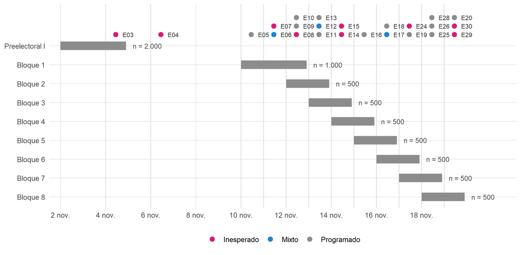

Figura 3: Bloques de trabajo de campo y eventos. Cada barra es un bloque de muestra independiente; los puntos marcan los eventos según fueran inesperados, programados o mixtos (véase la Tabla 1).

40dB utiliza cuotas de sexo por edad, comunidad autónoma, tamaño del municipio y clase social. Hemos ponderado cada bloque por separado con un *raking* hacia los mismos marginales poblacionales, tomados del fichero ponderado del día 4, para que las comparaciones entre días no dependan de qué fichero procede cada entrevista. Los pesos son poco dispersos (efecto de diseño de entre 1,02 y 1,07).

Hemos encontrado 291 entrevistas del tracking que son copias exactas de otra en las 31 variables (edad exacta, provincia, diez probabilidades de voto…), casi siempre en un día de trabajo de campo distinto. La proporción crece con el tiempo, desde un 1,8 % del bloque 1 hasta entre un 7 % y un 10 % de cada bloque a partir del 3. Probablemente son registros duplicados o panelistas reentrevistados. Las mantenemos en el análisis principal y las excluimos en una prueba de robustez.

### 2.2 Diseño

Seguimos el diseño de eventos inesperados durante el trabajo de campo (UESD, Muñoz et al. 2020), que compara a los encuestados entrevistados antes y después de un evento. La interpretación causal depende de dos supuestos. El primero es la **exclusión**: el momento de la entrevista solo afecta al resultado a través del evento. En una campaña es un supuesto exigente, porque cada día hay varios eventos, cada uno genera reacciones (eventos colaterales) y el voto puede seguir tendencias propias. El segundo es la **ignorabilidad temporal**: el día de la entrevista debe ser independiente de los resultados potenciales. El tracking la favorece, porque cada bloque es una muestra de cuotas nueva y completa, parecida a un *rolling cross-section* (Johnston y Brady 2002), pero en un panel en línea quienes responden un día concreto podrían diferir de quienes responden otro día.

La mayoría de los eventos de campaña no son inesperados en el sentido estricto del UESD: los debates, el inicio de la campaña y los programas estaban anunciados, y sus efectos podrían anticiparse. Clasificamos cada evento como inesperado, programado o mixto (Tabla 1).

Para cada día con eventos, un bloque es *pre* si terminó antes de ese día y *post* si empezó después. Los bloques que contienen el día del evento se excluyen de la estimación principal. Los eventos de un mismo día se estiman conjuntamente como un **día de eventos**. Las estimaciones son efectos de intención de tratar (ITT): no sabemos quién se enteró de cada evento, y el tracking no tiene ninguna pregunta sobre el problema más importante que permita una comprobación indirecta de la exposición.

El modelo principal es una regresión lineal ponderada de cada indicador sobre una variable *post*, con errores estándar HC2 y controles por las variables de cuota y el nivel de estudios, todas anteriores al tratamiento. El recuerdo de voto de 2023 no entra: tiende a ajustarse a la preferencia actual y, por tanto, un evento puede alterarlo, lo que introduciría sesgo postratamiento (Montgomery et al. 2018). Lo usamos como control en una especificación alternativa y como resultado placebo. Hasta el 12 de noviembre no hay ningún bloque del tracking completamente anterior a los eventos, y el grupo *pre* es la encuesta preelectoral; estas comparaciones, entre encuestas distintas y con eventos intermedios, son más débiles. Los valores *q* corrigen las comparaciones múltiples dentro de cada especificación (Benjamini y Hochberg 1995).

### 2.3 Eventos

Tabla 1: Eventos durante el trabajo de campo y bloques de comparación. * Fecha aproximada. La lista completa, con descripciones y fuentes, está en events/events_29N.csv.

| ID | Fecha | Evento | Tipo | Bloques antes | Bloques después |
| --- | --- | --- | --- | --- | --- |
| E03 | 4 nov.* | Dimisión del ministro Puente | Inesperado | — | 1, 2, 3, 4, 5, 6, 7, 8 |
| E04 | 6 nov. | Zapatero sigue investigado (Plus Ultra) | Inesperado | 0 | 1, 2, 3, 4, 5, 6, 7, 8 |
| E05 | 10 nov. | Programa del PP | Programado | 0 | 2, 3, 4, 5, 6, 7, 8 |
| E06 | 11 nov. | Huelga general por la vivienda y cargas policiales | Mixto | 0 | 2, 3, 4, 5, 6, 7, 8 |
| E07 | 11 nov. | Prórroga de la investigación a Zapatero | Inesperado | 0 | 2, 3, 4, 5, 6, 7, 8 |
| E08 | 12 nov. | Marlaska abre una investigación; Sánchez lo respalda | Inesperado | 0 | 3, 4, 5, 6, 7, 8 |
| E09 | 12 nov. | Votación de los decretos de vivienda | Programado | 0 | 3, 4, 5, 6, 7, 8 |
| E10 | 12 nov. | Macroencuesta del CIS | Programado | 0 | 3, 4, 5, 6, 7, 8 |
| E11 | 13 nov. | Inicio oficial de la campaña; programa de Vox | Programado | 0, 1 | 4, 5, 6, 7, 8 |
| E12 | 13 nov. | Entrevistas de Jordi Wild; Abascal renuncia | Mixto | 0, 1 | 4, 5, 6, 7, 8 |
| E13 | 13 nov.* | Debate económico en laSexta | Programado | 0, 1 | 4, 5, 6, 7, 8 |
| E14 | 14 nov.* | Agresión a un acto del PP en Hernani | Inesperado | 0, 1, 2 | 5, 6, 7, 8 |
| E15 | 14 nov.* | Récord de llegadas de cayucos a Canarias | Inesperado | 0, 1, 2 | 5, 6, 7, 8 |
| E16 | 15 nov. | Programa del PSOE; Sánchez llama ‘racista’ a Abascal | Programado | 0, 1, 2, 3 | 6, 7, 8 |
| E17 | 16 nov. | Lula en la Moncloa; programa de Frente Amplio; informe del CNI sobre Ceuta | Mixto | 0, 1, 2, 3, 4 | 7, 8 |
| E18 | 16 nov.* | Entrevista a Sánchez en Telecinco (Ceuta) | Programado | 0, 1, 2, 3, 4 | 7, 8 |
| E19 | 17 nov. | Subida de sueldo a los funcionarios y del salario mínimo | Programado | 0, 1, 2, 3, 4, 5 | 8 |
| E24 | 17 nov. | La mujer de Abascal cobra el bono social térmico | Inesperado | 0, 1, 2, 3, 4, 5 | 8 |
| E25 | 18 nov. | Entrevista a Feijóo en el pódcast El sentido de la birra | Programado | 0, 1, 2, 3, 4, 5, 6 | — |
| E26 | 18 nov. | Entrevista a Sánchez en Antena 3 | Programado | 0, 1, 2, 3, 4, 5, 6 | — |
| E28 | 18 nov. | La Diputación Permanente convalida siete decretos ley | Programado | 0, 1, 2, 3, 4, 5, 6 | — |
| E29 | 19 nov. | Entrevista a Puigdemont en El Mundo | Inesperado | 0, 1, 2, 3, 4, 5, 6, 7 | — |
| E30 | 19 nov. | Informe policial: la entrada masiva en Ceuta fue planificada | Inesperado | 0, 1, 2, 3, 4, 5, 6, 7 | — |
| E20 | 19 nov. | Cara a cara Sánchez–Feijóo | Programado | 0, 1, 2, 3, 4, 5, 6, 7 | — |

El 10 y el 11 de noviembre comparten grupos de comparación y tienen estimaciones idénticas. Los eventos del 18 y 19 de noviembre aún no tienen ningún bloque posterior.

### 2.4 Diagnósticos

Tabla 2: Diagnósticos por día de eventos. Balance conjunto: prueba de Wald de las covariables no de cuota y el recuerdo de voto como predictores de ser entrevistado después. NS/NC: diferencia post − pre en puntos (valor p). Potencia: probabilidad de detectar un efecto de 5 puntos en la intención de voto a Vox.

| Día | Grupo pre | n pre/post | Balance conjunto | Placebos p<0,05 | NS/NC intención | NS participación | Potencia (5 p.) |
| --- | --- | --- | --- | --- | --- | --- | --- |
| 11 nov. E06, E07 | Preelectoral I | 2000/3500 | χ²(17) = 18,0, p = 0,392 | 0/5 | −0,4 (0,28) | −0,1 (0,84) | 1,00 |
| 12 nov. E08, E09, E10 | Preelectoral I | 2000/3000 | χ²(17) = 20,4, p = 0,254 | 1/5 | −0,3 (0,42) | 0,0 (0,91) | 0,99 |
| 13 nov. E11, E12, E13 | Tracking | 1000/2500 | χ²(17) = 19,8, p = 0,285 | 0/5 | −0,7 (0,19) | +0,6 (0,17) | 0,92 |
| 14 nov. E14, E15 | Tracking | 1500/2000 | χ²(17) = 23,7, p = 0,129 | 1/5 | −0,2 (0,63) | +0,7 (0,10) | 0,96 |
| 15 nov. E16 | Tracking | 2000/1500 | χ²(17) = 25,2, p = 0,091 | 0/5 | 0,0 (0,94) | +0,2 (0,55) | 0,97 |
| 16 nov. E17, E18 | Tracking | 2500/1000 | χ²(17) = 18,7, p = 0,343 | 0/5 | 0,0 (0,93) | 0,0 (0,99) | 0,93 |
| 17 nov. E19, E24 | Tracking | 3000/500 | χ²(17) = 16,2, p = 0,507 | 0/5 | +0,2 (0,82) | −0,4 (0,45) | 0,78 |

**Balance.** Para cada día de eventos, ninguna prueba conjunta de las covariables no de cuota (estudios, situación laboral, hijos en el hogar) y del recuerdo de voto es significativa (Tabla 2). Para el 13 de noviembre todas las diferencias estandarizadas son inferiores a 0,1 (Figura 4). Las variables de cuota están balanceadas por construcción una vez ponderado cada bloque. La composición por recuerdo de voto no varía entre los 8 bloques del tracking (*F* = 0,56, p = 0,991), y solo 2 de las 45 pruebas placebo sobre el recuerdo de voto son significativas al 5 %, más o menos las que cabría esperar por puro azar; ninguna sobrevive a la corrección por comparaciones múltiples.

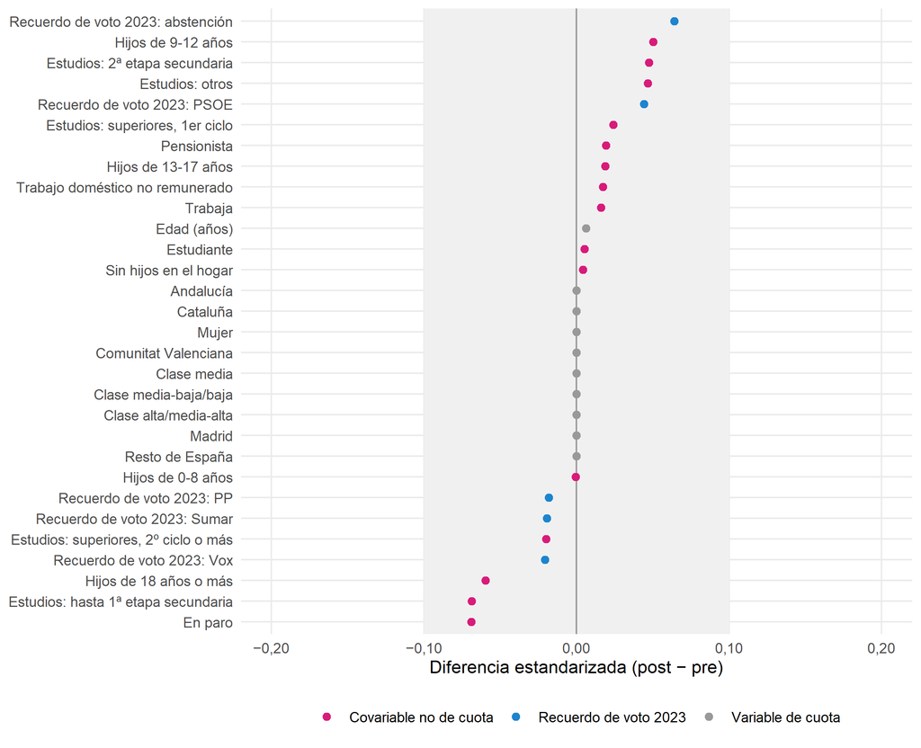

Figura 4: Balance de covariables entre los grupos pre (bloque 1) y post (bloques 4 a 8) del 13 de noviembre. La franja gris marca diferencias estandarizadas inferiores a 0,1.

**No respuesta parcial.** La proporción que se niega a declarar su intención de voto es estable. La que no sabe si irá a votar crece ligeramente después del 13 y el 14 de noviembre (de un 1 % a un 2 %, aproximadamente), pero la diferencia no es significativa.

**Estabilidad del periodo previo.** La prueba placebo de dividir el grupo de control por la mediana de días no es posible, porque el bloque 1 no tiene fechas individuales. Como alternativa, comparamos el bloque 1 con la encuesta preelectoral: la diferencia de Vox es de +2,1 puntos (p = 0,171), no significativa pero en la dirección que podría inflar la caída posterior.

**Potencia.** El efecto mínimo detectable con una potencia del 80 % para la intención de voto a Vox es de 4,1 puntos el 13 de noviembre y de 3,7 el 14. Ninguna prueba global de diferencias entre los 8 bloques del tracking sobrevive a la corrección por comparaciones múltiples (*q* mínimo = 0,75; sin corregir, Vox p = 0,042 y Abascal como mejor presidente p = 0,077).

### 2.5 Resultados detallados

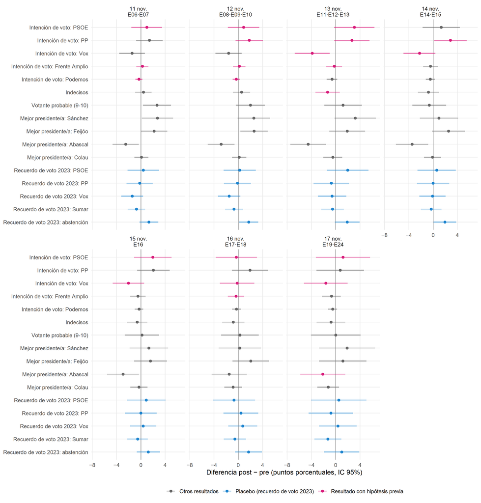

Figura 5: Diferencias post − pre por día de eventos (especificación principal). Para el 11 y el 12 de noviembre el grupo pre es la encuesta preelectoral; a partir del 13, los bloques del tracking anteriores al evento. Magenta: indicadores con hipótesis previa; azul: placebos.

Tabla 3: 13 de noviembre: diferencias entre los encuestados del 14-19 y del 10-12 de noviembre. Pre: porcentaje en el bloque 1. Regresión lineal ponderada con controles de cuota y estudios; errores HC2; q: valores de Benjamini-Hochberg.

| Indicador | Pre (%) | Diferencia (puntos) | IC 95% | p | q |
| --- | --- | --- | --- | --- | --- |
| Intención de voto: PSOE | 26,6 | +3,1 | [−0,3; 6,4] | 0,071 | 0,55 |
| Intención de voto: PP | 19,9 | +2,7 | [−0,3; 5,6] | 0,074 | 0,55 |
| Intención de voto: Vox | 20,0 | −3,9 | [−6,8; −1,0] | 0,009 | 0,26 |
| Intención de voto: Frente Amplio | 3,3 | −0,3 | [−1,6; 1,1] | 0,702 | 0,85 |
| Intención de voto: Podemos | 1,6 | −0,6 | [−1,5; 0,3] | 0,163 | 0,64 |
| Indecisos | 8,5 | −1,3 | [−3,4; 0,7] | 0,189 | 0,64 |
| Votante probable (9-10) | 75,8 | +1,2 | [−1,9; 4,3] | 0,446 | 0,74 |
| Mejor presidente/a: Sánchez | 29,3 | +3,2 | [−0,2; 6,6] | 0,065 | 0,55 |
| Mejor presidente/a: Feijóo | 21,0 | +1,9 | [−1,1; 4,8] | 0,211 | 0,64 |
| Mejor presidente/a: Abascal | 21,1 | −4,5 | [−7,5; −1,6] | 0,002 | 0,18 |
| Mejor presidente/a: Colau | 4,8 | −0,5 | [−2,0; 1,1] | 0,533 | 0,78 |

Las caídas de Abascal como mejor presidente (−4,5 puntos (p = 0,002; q = 0,18)) y de Vox (−3,9 puntos (p = 0,009; q = 0,26)) tienen los valores *q* más bajos del 13 de noviembre, pero con 75 pruebas en la especificación principal ninguno baja de 0,1. La del PSOE es de +3,1 puntos (p = 0,071; q = 0,55) y la del PP, de +2,7 puntos (p = 0,074; q = 0,55). La caída de Vox y de Abascal es significativa en las 8 especificaciones de la Figura 6. Cuando los bloques que contienen el día 13 se tratan como posteriores, el efecto sobre Vox se atenúa hasta −3,5 puntos (p = 0,013), y con la encuesta preelectoral añadida al grupo *pre* es de −2,5 puntos (p = 0,017). La ganancia del PP es significativa en 2 de las 8 especificaciones, y la del PSOE, en 2.

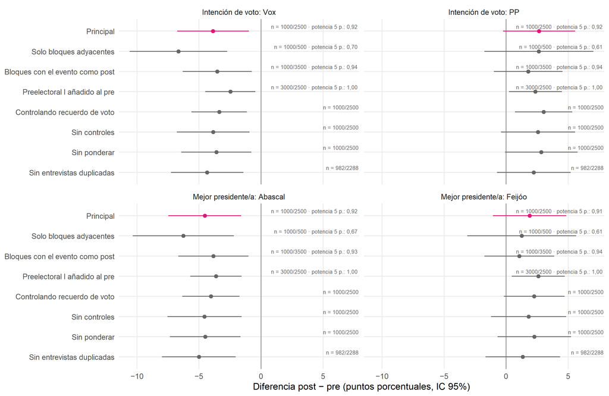

Figura 6: Robustez de las estimaciones del 13 de noviembre. Para cada especificación se indica el tamaño de los grupos pre/post y, para las variaciones de ventana, la potencia para detectar un efecto de 5 puntos.

**Heterogeneidad.** La Figura 7 muestra los efectos en grupos definidos antes de estimar. Entre los hombres de 18 a 34 años, la diferencia en la intención de voto a Vox el 13 de noviembre es de −6,7 puntos (p = 0,211) (103 encuestados pre y 250 post), concentrada sobre todo en el bloque 4. Entre los votantes del PSOE y Sumar de 2023, la diferencia en la intención de voto a Frente Amplio tras la huelga es de +0,6 puntos (p = 0,559) y en la del PSOE, de +1,7 puntos (p = 0,430). Para el 14 de noviembre, la diferencia para el PP es de +2,8 puntos (p = 0,037), pero el grupo *pre* incluye bloques anteriores al 13 de noviembre y hereda la tendencia de ese día, una violación del supuesto de exclusión por tendencia temporal (Muñoz et al. 2020). Las falsaciones regionales (H4 y H5) solo tienen 122 y 88 casos en el grupo post. Las heterogeneidades por recuerdo de voto (H1, H3) y los flujos de voto deben leerse con cautela, porque el moderador podría estar afectado por el tratamiento.

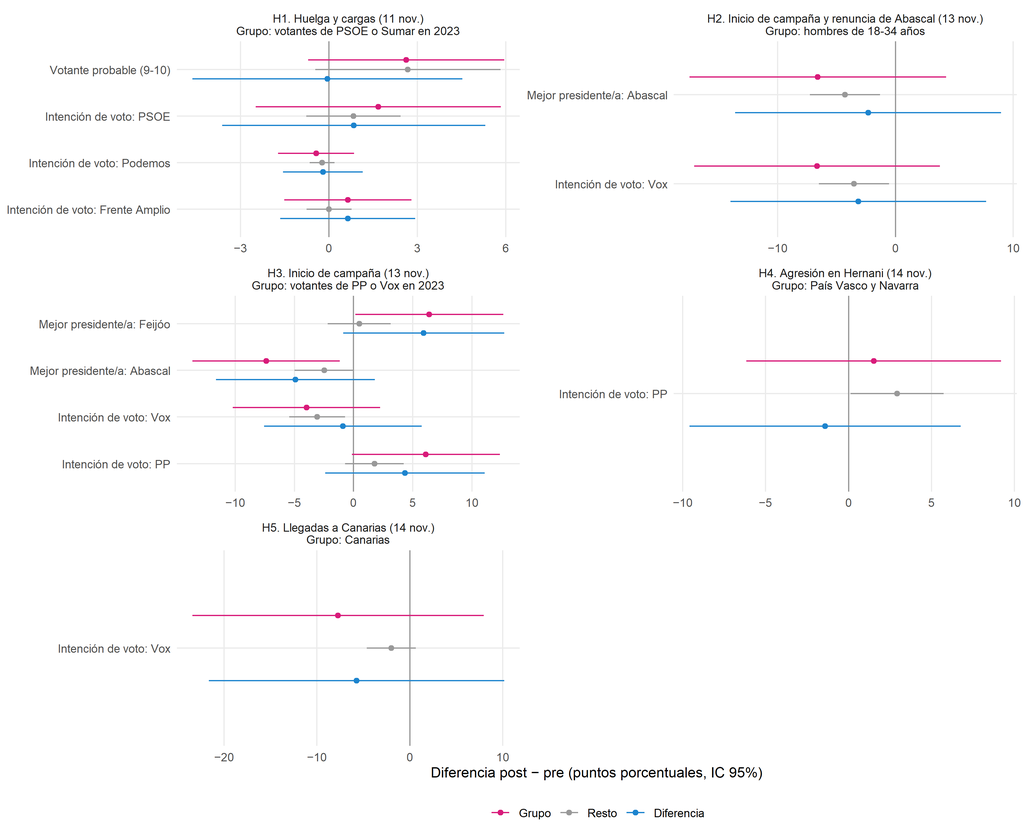

Figura 7: Efectos por grupos definidos a priori. Grupo: diferencia post − pre dentro del grupo; Resto: fuera del grupo; Diferencia: interacción.

## Referencias

40dB. 2026a. *Encuesta preelectoral I, noviembre de 2026*. Microdatos, cuestionario, nota metodológica, tablas e informe. Encuesta para El País y la Cadena SER. https://ep00.epimg.net/infografias/encuestas40db/2026/11-preelectoral/2026_11_preelectoral_descargables.zip.

Benjamini, Yoav, y Yosef Hochberg. 1995. «Controlling the False Discovery Rate: A Practical and Powerful Approach to Multiple Testing». *Journal of the Royal Statistical Society: Series B (Methodological)* 57 (1): 289-300. https://doi.org/10.1111/j.2517-6161.1995.tb02031.x.

El País. 2026. «Vox se frena y cede terreno al PP». *El País*, noviembre 17. https://elpais.com/espana/elecciones-generales/2026-11-17/vox-se-frena-y-cede-terreno-al-pp.html.

Johnston, Richard, y Henry E. Brady. 2002. «The Rolling Cross-Section Design». *Electoral Studies* 21 (2): 283-95. https://doi.org/10.1016/S0261-3794(01)00022-1.

Montgomery, Jacob M., Brendan Nyhan, y Michelle Torres. 2018. «How Conditioning on Posttreatment Variables Can Ruin Your Experiment and What to Do about It». *American Journal of Political Science* 62 (3): 760-75. https://doi.org/10.1111/ajps.12357.

Muñoz, Jordi, Albert Falcó-Gimeno, y Enrique Hernández. 2020. «Unexpected Event during Survey Design: Promise and Pitfalls for Causal Inference». *Political Analysis* 28 (2): 186-206. https://doi.org/10.1017/pan.2019.27.

Shaw, Daron R. 1999. «A Study of Presidential Campaign Event Effects from 1952 to 1992». *The Journal of Politics* 61 (2): 387-422. https://doi.org/10.2307/2647509.